[figure not shown]

# #RealCollegeCA Survey Results

## Spring 2025

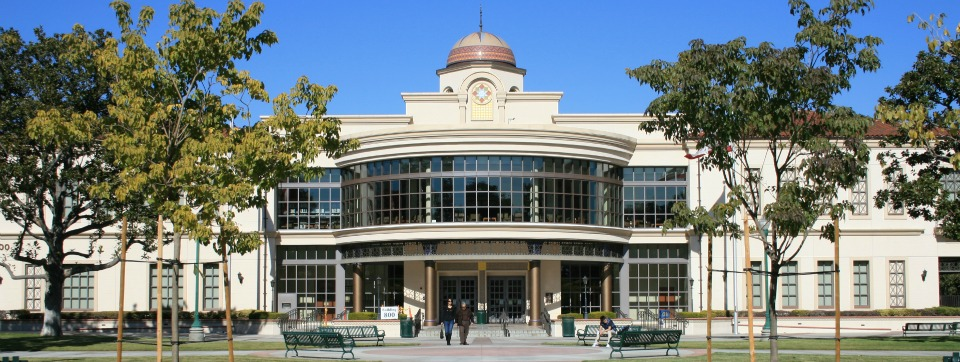

# About the Survey

In spring 2025, Fullerton College (FC) participated in the [Real College California Survey](https://www.rpgroup.org/resources/realcollege-ca-basic-needs-among-ccc-students-in-2025), a state-wide survey of student’s basic needs in the California Community College System. The survey was adapted from the largest national survey of basic needs among college students with modifications made to reflect the unique characteristics and needs of the California Community College population.

The online survey was administered to all currently enrolled FC students. To encourage students to complete the survey, $250 incentives were offered to participants via random lottery. Overall, 1,164 FC students completed the survey with a response rate of about 6%, which is typical of campuswide surveys.

Overall, the survey respondents were representative. White students were over-represented (see [Race/Ethnicity](https://wu-vinnie.github.io/reports/RealCollegeCA_RaceEthnicity.html)), as were female students (see [Gender](https://wu-vinnie.github.io/reports/RealCollegeCA_Gender.html)) and full-time students (see [Full-Time Status](https://wu-vinnie.github.io/reports/RealCollegeCA_FullTime.html)).

The survey considered three areas of basic needs:

**Food Insecurity**: defined as the limited or uncertain availability of nutritionally adequate and safe food, or the ability to acquire such food in a socially acceptable manner.

**Housing Insecurity**: defined as a broad set of challenges such as the inability to pay rent or utilities, or the need to move frequently.

**Homelessness**: defined as not having a stable place to live. Students were identified as homeless if they self-identified as homeless or if they identified living conditions that were considered signs of homelessness (e.g. couch surfing or living somewhere not meant for habitation).

Additionally, the survey investigated the extent to which students experienced **at least one of these three basic needs insecurities**.

## Limitations and Considerations

As with any voluntary survey, the findings in this report should be interpreted with care. While the sample is generally representative of the Fullerton College student body, participation was self-selected, and certain groups may be underrepresented. Since the survey was distributed electronically, students needed access to the internet and a device to participate, which are factors related to basic needs access, so overall rates of need may be underestimated. In addition, participation was self-selected, meaning that those who chose to respond may differ from the broader student population.

The 2023 and 2025 surveys also included different samples of colleges and students, so results across years should be viewed as indicative of general trends rather than exact one-to-one comparisons. **Together, these results provide valuable insights into student experiences, but they are best understood as indicators of broader patterns rather than exact population estimates.**

# Basic Needs Overview

**From 2023 to 2025, rates of basic needs insecurity at FC increased by approximately 3.8 percentage points (pts) on average across all measures (food, housing, and homelessness).** In particular, the share of students reporting any form of insecurity rose from 59% to 62% (see Figure 1).

These findings suggest that while basic needs challenges have grown locally since 2023, FC continues to track slightly below statewide levels.

**Figure 1:** Basic Needs Insecurity Comparison to FC 2023 and Statewide in 2025

[interactive chart not shown]

Figure 1

# Demographic Differences

## Summary

In this section, the extent to which Fullerton College students experience basic needs is disaggregated. In spring 2025, results revealed that while patterns generally mirror statewide findings, the magnitude of inequities varies across groups. Overall, basic needs insecurities affect the majority of Fullerton College students, underscoring the need for continued institutional commitment to equity-driven resource coordination, targeted outreach, and demographically responsive support for all students.

## [**Race/Ethnicity**](https://fc-oie.github.io/docs/RealCollegeCA/2025/ethnicity.html)

**Pacific Islander and Native Hawaiian students** report the highest rates of both food and housing insecurity, followed closely by **Middle Eastern and North African students**, who also experienced elevated levels across these domains. Both these groups experience **small sample sizes**, so results should be cautiously interpreted. **Black or African American students** continue to face substantial challenges across all basic needs areas, with many experiencing food insecurity and the majority reporting at least one form of insecurity.

**Latina/o/x students**, who represent a large portion of the student body, also report persistently high levels of food and housing insecurity. Although **American Indian or Alaska Native**, **White**, and **Asian subgroups** (South, East, and Southeast) report comparatively lower rates, basic needs insecurity still affected a significant share of students within these groups.

[Read the full report on race/ethnicity!](https://fc-oie.github.io/docs/RealCollegeCA/2025/ethnicity.html)

## [**Gender**](https://fc-oie.github.io/docs/RealCollegeCA/2025/ethnicity.html)

**Transgender** students consistently experience the highest levels of food insecurity, housing insecurity, homelessness, and at least one basic needs insecurity, with rates exceeding campuswide averages across every measure. **Non-binary** students also show elevated levels across domains, with food insecurity, housing insecurity, homelessness, and overall basic needs insecurity, all falling above institutional benchmarks. However, it is important to note that these groups have **small sample sizes**, so their rates should be interpreted with caution even as the patterns remain meaningful.

**Female** and **male** students experience comparatively lower levels of basic needs insecurity, with rates that generally align with or fall slightly below campuswide averages across all measures. These groups show less variation and substantially lower need relative to transgender and non-binary students.

Overall, **basic needs insecurity is most pronounced among transgender and non-binary students**, while female and male students face comparatively lower levels of need across all domains.

[Read the full report on gender!](https://fc-oie.github.io/docs/RealCollegeCA/2025/gender.html)

## [**Sexual Orientation**](https://fc-oie.github.io/docs/RealCollegeCA/2025/sexualorientation.html)

**Gay** and **same-gender loving** students consistently experience the highest levels of housing insecurity and at least one basic needs insecurity, with homelessness rates also above the campuswide averages. **Pansexual** students show similarly elevated patterns, including high levels of homelessness and overall insecurity. **Bisexual** and **queer** students generally fall near the institutional averages, with moderate levels of housing insecurity, food insecurity, and homelessness. **Lesbian** students show mixed patterns—lower food insecurity but elevated homelessness compared to other groups. **Questioning/unsure** students consistently report the lowest levels of need across all domains.

It is important to keep in mind that several of these groups have **small sample sizes**, which means their rates may be more variable and should be interpreted with caution. However, many of these patterns are consistent with patterns from the 2023 survey. Overall, **gay, same-gender loving, and pansexual students experience the highest levels of basic needs insecurity**, while **questioning/unsure students report the lowest**, with other groups falling in between depending on the specific measure.

[Read the full report on sexual orientation!](https://fc-oie.github.io/docs/RealCollegeCA/2025/sexualorientation.html)

## [**Full-Time Status**](https://fc-oie.github.io/docs/RealCollegeCA/2025/fulltime.html)

Full-time students were somewhat overrepresented in the survey sample, but overall, **full-time** and **part-time** students show very similar levels of food insecurity, housing insecurity, homelessness, and experiencing at least one basic needs insecurity. Minor differences appear in a few areas, but none of these gaps are substantial.

[Read the full report on full-time status!](https://fc-oie.github.io/docs/RealCollegeCA/2025/fulltime.html)

## [**Additional Demographics**](https://fc-oie.github.io/docs/RealCollegeCA/2025/demo.html)

Across all basic needs in 2025, substantial disparities appear among key student groups. **Single parents**, **justice-impacted/formerly incarcerated students**, and **foster youth/former foster care students** consistently experience the highest levels of food insecurity, housing insecurity, homelessness, and at least one basic needs insecurity, with rates often far exceeding campuswide averages. These groups show the most severe and persistent basic needs challenges.

Students with **any disability**, **parents/guardians**, and **veterans** also report elevated levels across multiple indicators, typically falling well above institutional averages for housing insecurity and at least one insecurity, and moderately above for food insecurity and homelessness.

Students who **provide care for a family member** and **first-generation college students** show moderately elevated levels of basic needs insecurity, with rates consistently above campuswide benchmarks but lower than the highest-need groups.

Overall, **basic needs insecurity is most pronounced among single parents, justice-impacted students, and foster youth**, while several other groups face consistently elevated levels of need across all measures.

[Read the full report on additional demographics!](https://fc-oie.github.io/docs/RealCollegeCA/2025/demo.html)

# Effects on Academic Performance

As consistent with the statewide data, **students who reported lower academic grades were more likely to also report experiencing insecurities related to basic needs**. This suggests that basic needs challenges may be linked to lower academic performance.

This underscores the importance of comprehensive basic needs support to promote student success. Notably, students experiencing homelessness were also more likely to withdraw from their classes, highlighting the urgent need for targeted outreach and resources for this group.

**Figure 2:** Rates of Basic Needs Insecurities by Self-Reported Grades

[interactive chart not shown]

Figure 2

# Basic Needs Support at FC

[figure not shown]

## Overview

The Hornets Resource Center (HRC) and Food Bank play a vital role in supporting Fullerton College students by connecting them with food, housing, mental health, and other essential resources that promote well-being and academic success. The link below summarizes students’ awareness and use of these supports.

Most respondents reported having heard of the HRC and Food Bank, and many of those students have already accessed its services, most commonly for food assistance, followed by housing and mental health support. At the same time, some students expressed uncertainty about eligibility or how to access available resources, suggesting opportunities to continue strengthening outreach and communication.

Overall, the findings affirm the growing impact of the HRC and Food Bank and underscore the importance of continued collaboration to ensure that all students feel informed, welcomed, and supported in meeting their basic needs.

## [Learn more about how FC supports basic needs!](https://fc-oie.github.io/docs/RealCollegeCA/2025/fcbasicneeds.html)

# Mental Health

Mental health challenges are closely intertwined with basic needs insecurities. Students experiencing food insecurity, housing insecurity, or homelessness often face mental health concerns (e.g., depression, anxiety, eating disorders, self-injury, suicidal ideation) that can impede their academic success and overall well-being.

The Healthy Minds Study (HMS) is a national survey that assesses mental health and related factors among college students. In spring 2025, Fullerton College participated in HMS alongside the Real College California Survey. Follow the link below to learn about key mental health indicators. This survey additionally asked about food and housing insecurity, allowing for analysis of how basic needs challenges intersect with mental health.

Findings demonstrate that nearly eight in ten food-insecure students (79%) indicated experiencing at least one mental health condition, versus 68% among food-secure students. Additionally, more than four in five housing-insecure students (81%) reported at least one mental health condition, compared with 68% of students who were housing secure.

## [Learn about mental health challenges at FC!](https://fc-oie.github.io/docs/HealthyMinds/2025/report.html)